# 331 Final Project

### Animated Visualization: Sugar Consumption vs. Health Spending Over Time

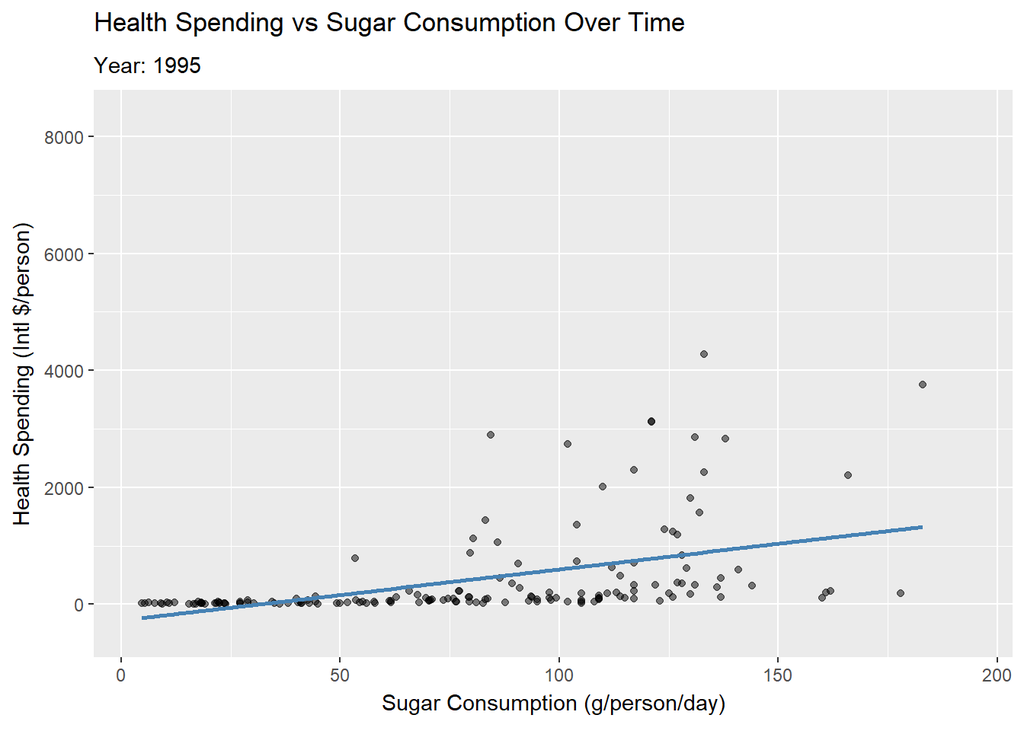

This animation shows how the relationship between sugar consumption (g/person/day) and health spending (Intl $/person) has changed across countries from 1995 to 2010. Each point represents a country in a given year, and the blue line shows the trend for that year using linear regression.

While the overall association remains positive, the strength and spread of this relationship fluctuate. For example, from the late 1990s onward, some countries exhibit rapid increases in spending despite stable sugar levels, suggesting the influence of confounding factors such as economic development or healthcare policy.

## Linear Model

To further examine the relationship between sugar consumption and health spending, we fit a linear regression model using average sugar consumption as the predictor and average health spending as the response, using country-level averages. We summarized our data set by averaging sugar consumption and health spending across all years by country. This stabilizes the trendline under animation, as it abstracts away intra-year fluctuations while still incorporating an adequately long period of data collection.

We fit the following linear regression model:

$$\hat{y} = -502.829 + 14.035x$$

where $\hat{y}$ is average healthcare spending per person per year, and $x$ is average daily sugar intake (g/person/day).

Linear Regression Coefficients

|  | Estimate | Std_Error | t_value | p_value |
| --- | --- | --- | --- | --- |
| (Intercept) | -502.829 | 177.412 | -2.834 | 0.00517 |
| avg_sugar | 14.035 | 1.914 | 7.334 | 0.00000 |

The intercept implies that countries with near-zero sugar consumption would have an estimated health spending of $-503 (not interpretable in isolation). The minimum observed sugar consumption across all countries was approximately 7.618 grams/day, confirming that the intercept at ~ -503 is an extrapolation outside the data range. The slope indicates that for every additional gram of sugar consumed per person per day, a country’s average health spending increases by approximately $14.04 per year, holding other factors constant.

## Model Fit

### Decomposition of Model Variance

The following table breaks down the total variation in the outcome variable into explained and unexplained components:

Analyzing Model Variance

| Model Fit Variables | Value |
| --- | --- |
| variance in response values | 1410958.241 |
| variance in fitted values | 350040.643 |
| variance in residuals | 1060917.598 |
| r-squared | 0.248 |

The R² value of 0.248 indicates that sugar consumption explains 24.8% of the variability in health spending across countries. This suggests a moderate association, but also implies that 75.2% of spending variation is likely driven by a multitude of other factors, such as economic development or healthcare policy.

## Cross Validation

```
 [1]  0.08901934  2.08033802  1.50571501  0.22974073  0.03571885  0.57156824
 [7]  0.26344297  0.18883690  0.95914753  0.24124309 15.11158664  0.50671016
[13]  0.30705568  0.18275002  0.11039892
```

# References

Berthold, J. (2023, April 21). Sugary drink tax improves health, lowers health care costs: Sweetened beverage purchases drop 27% in Oakland, signaling potential impact of national legislation. University of California, Berkeley. Sugary drink tax improves health, lowers health care costs. https://publichealth.berkeley.edu/articles/spotlight/research/sugary-drink-tax-improves-health

Food and Agriculture Organization. (2024). FAOSTAT: Sugar & sweeteners food supply data. http://data.un.org/Data.aspx?q=Sugar&d=FAO&f=itemCode:2909

World Health Organization. (2024). Global Health Expenditure Database. https://apps.who.int/nha/database